# OfficeMate Technical Appendix

## 7.2 Quantitative variables using GGpairs

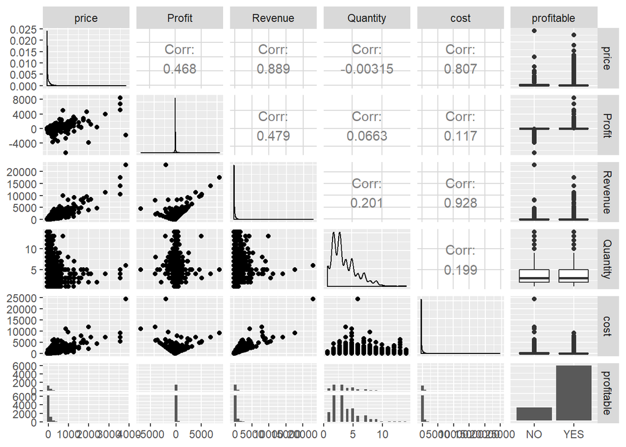

```r
# ggparis on all quant. variables

od %>%
  select(price, Profit, Revenue, Quantity, cost, profitable) %>%
  ggpairs()
```

- this is messy and confirms what we say in the multivariate non-graphical
  - we can see all the correlations as same as mentioned in the multivariate non-graphical
  - perhaps there is a better way to graph the quantitative variables?

### 7.2.1 scatter plots

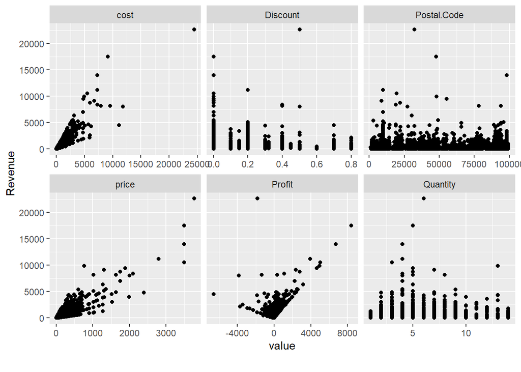

```r
#Scatter of numeric variables by Revenue
od %>%
  select_if(is.numeric) %>%
  plot_scatterplot(by = "Revenue")
```

- This is a bit messy but once again shows exactly what we mentioned above

  -Price more than 3000 have the highest revenue -Revenue generated/gathered the most when price is lower than 1000 in term of quantity -There is a highest revenue point of more than 20000 but generated a negative profit

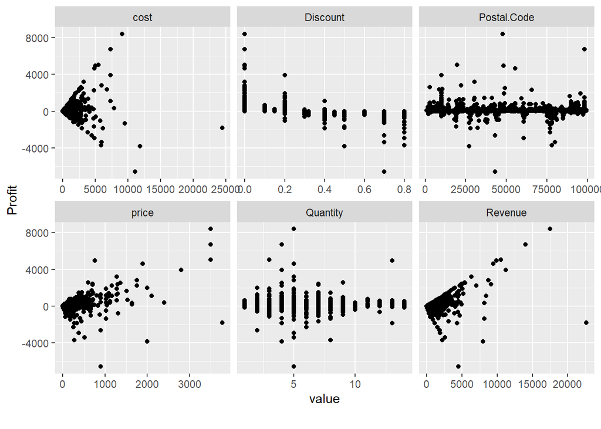

```r
#Scatter of numeric variables by Profit
od %>%
  select_if(is.numeric) %>%
  plot_scatterplot(by = "Profit")
```

- Similar graphs but for Profit

  -Has the most profit when cost is around 9000 -Show the same thing in related to revenue as shown in the above graph -Most profits generated when quantity is at 2,3 but has the highest profit when quantity = 5

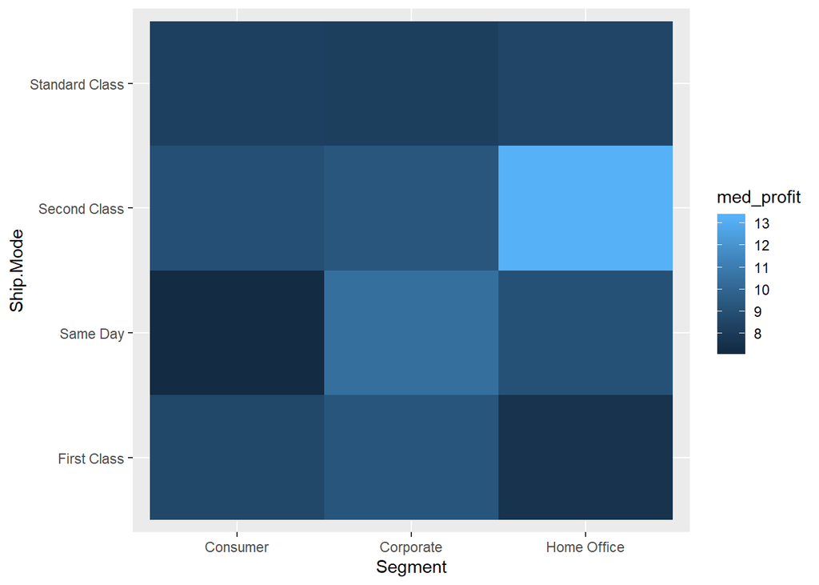

```r
od %>%
  group_by(Segment, Ship.Mode) %>%
  summarise(med_profit = median(Profit)) %>%
  ggplot(aes(Segment, Ship.Mode)) +
  geom_tile(aes(fill = med_profit))
```

- Second Class generates most profits from Home Office segment
  - no new questions raised here

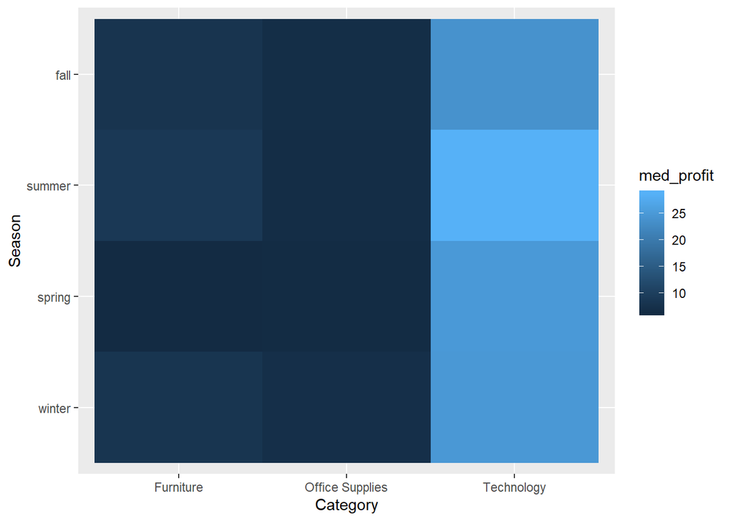

```r
od %>%
  group_by(Category,Season) %>%
  summarise(med_profit = median(Profit)) %>%
  ggplot(aes(Category,Season)) +
  geom_tile(aes(fill = med_profit))
```

- Technology brought the most profits in 4 seasons in term of med-profit
  - can clearly see the highest median profit in Technology for summer
  - Techonology seems to do reall well in terms of gaining profit throughout the year

# 8 Detailed EDA

## 8.1 all segment and category using median profit

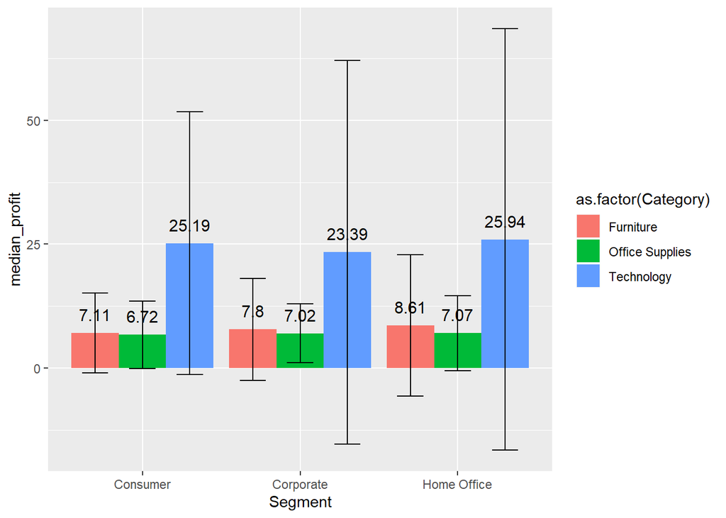

```r
# 95% CI to get upper tail 0.975 is one-sided
z <- qnorm(0.975)

# incorporate CI into graphs
od %>%
  group_by(Segment, Category) %>%
  summarise(median_profit = median(Profit), n = n(), sd = sd(Profit), ci = z * sd/sqrt(n)) %>%
  ggplot(aes(x = Segment, y = median_profit, fill = as.factor(Category))) +
  geom_bar(stat = "identity", position = "dodge") +
  geom_text(aes(label = round(median_profit, 2)), vjust = -1, color = "black", position = position_dodge(0.9), size = 4) +
  geom_errorbar(aes(ymin = median_profit - ci, ymax = median_profit + ci), width = 0.5, position = position_dodge(0.9))
```

- Technology has the highest profit across all segments
  - this is most likely due to Technology has a large amount of Revenue and a lower cost
  - there is not a significant difference between office supplies and furniture in term of profit in all 3 segments.

## 8.2 (price per unit)

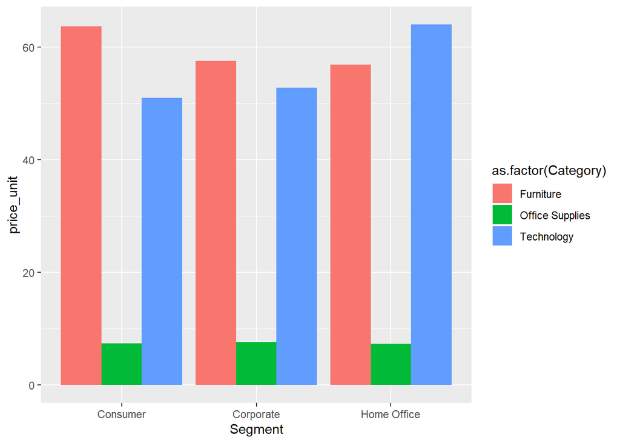

```r
# 95% CI to get upper tail 0.975 is one-sided
z <- qnorm(0.975)

# incorporate CI into graphs
od %>%
  group_by(Segment, Category) %>%
  summarise(price_unit = median(price), n = n(), sd = sd(Profit), ci = z * sd/sqrt(n)) %>%
  ggplot(aes(x = Segment, y = price_unit, fill = as.factor(Category))) +
  geom_bar(stat = "identity", position = "dodge")
```

## 8.3 sum of profit across categories (discount_eligible)

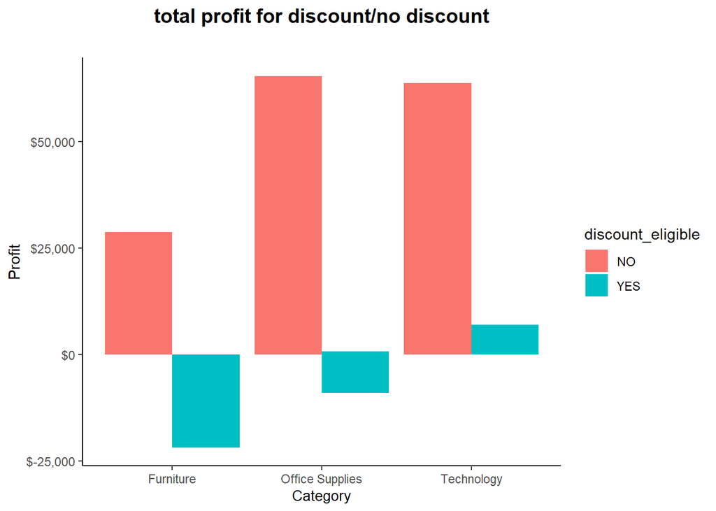

```r
options(scipen = 999)
#increase profit with discount?
discount_rev_plot <- od %>%
  group_by(Segment,Category, discount_eligible) %>%
  summarise(sum_profit = sum(Profit)) %>%
  #filter(any(Segment ='Office Supplies')) %>%
  ggplot(aes(x = Category, y = sum_profit, group = discount_eligible, fill = discount_eligible)) +
  geom_bar(stat = "identity", position = "dodge") +
  theme_classic() +
  labs(x = "Category", y = "Profit", title = "total profit for discount/no discount",
       subtitle = "") +
  theme(plot.title = element_text(face = "bold", hjust = 0.5, size = 14),
        plot.subtitle = element_text(hjust = 0.5, face = "italic", size = 12),
        axis.title.x = element_text(size = 10)) +
  scale_y_continuous(labels = dollar)
  #geom_hline(aes(yintercept = 0))



discount_rev_plot
```

## 8.4 sum of profit across categories (profitable)

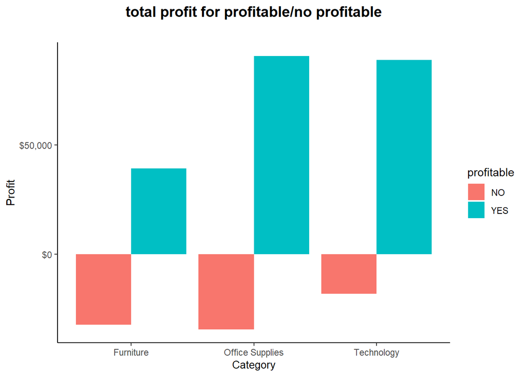

```r
options(scipen = 999)
#increase profit if it is profitable?
pro_profit_plot <- od %>%
  group_by(Segment,Category, profitable) %>%
  summarise(sum_profit = sum(Profit)) %>%
  ggplot(aes(x = Category, y = sum_profit, group = profitable, fill = profitable)) +
  geom_bar(stat = "identity", position = "dodge") +
  theme_classic() +
  labs(x = "Category", y = "Profit", title = "total profit for profitable/no profitable",
       subtitle = "") +
  theme(plot.title = element_text(face = "bold", hjust = 0.5, size = 14),
        plot.subtitle = element_text(hjust = 0.5, face = "italic", size = 12),
        axis.title.x = element_text(size = 10)) +
  scale_y_continuous(labels = dollar)

pro_profit_plot
```

- this graph shows the relationship between profitable and total profit on each category
  - again, it seems like the company do not make any profit out of Furniture -the non-profitable and profitable portions are very close to each other
  - office supplies also have a big amount of non-profitable sales while technology, as expected have a small portion of it

## 8.5 segment median of profit across categories (discount_eligible)

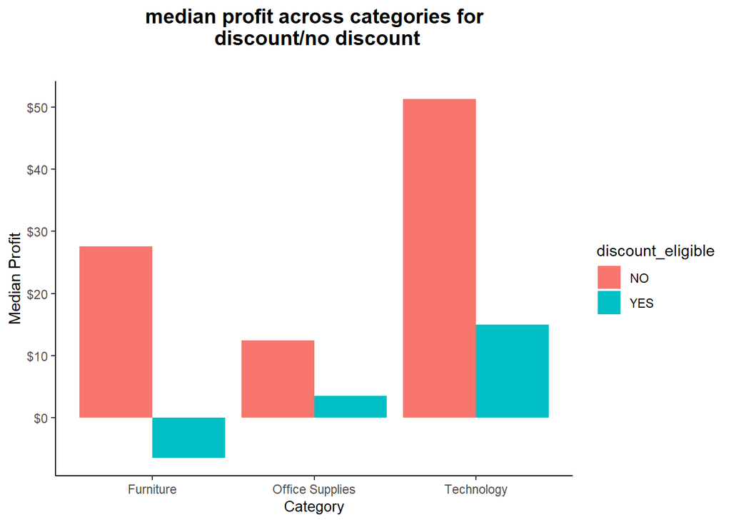

```r
options(scipen = 999)
#increase profit with discount?
med_discount_rev_plot <- od %>%
  group_by(Segment,Category, discount_eligible) %>%
  summarise(med_profit = median(Profit)) %>%
  ggplot(aes(x = Category, y = med_profit, group = discount_eligible, fill = discount_eligible)) +
  geom_bar(stat = "identity", position = "dodge") +
  theme_classic() +
  labs(x = "Category", y = "Median Profit", title = "median profit across categories for\n discount/no discount",
       subtitle = "") +
  theme(plot.title = element_text(face = "bold", hjust = 0.5, size = 14),
        plot.subtitle = element_text(hjust = 0.5, face = "italic", size = 12),
        axis.title.x = element_text(size = 10)) +
  scale_y_continuous(labels = dollar)

med_discount_rev_plot
```

- this graph shows the relationship between having discount and profit on each category across all segments
  - discounts seem not to make any impact on gaining the profit -there are even losses under furniture category
    - this could due to a high discount that makes price very low and can not generate enough revenue to cover the actual cost

## 8.6 segment median of profit across categories (profitable)

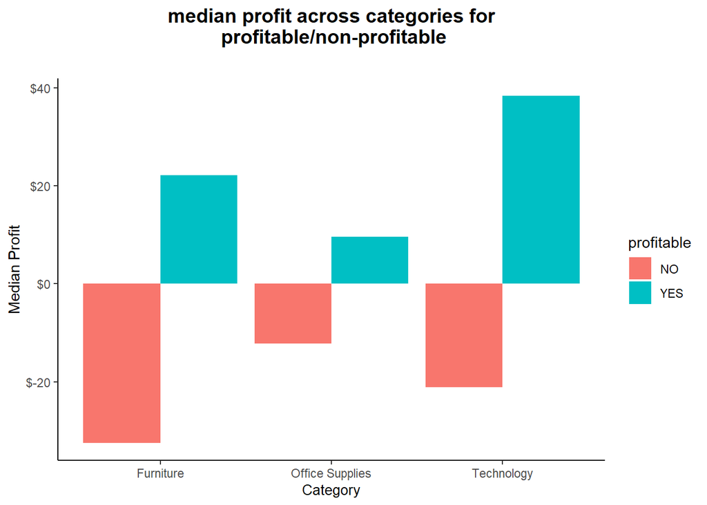

```r
options(scipen = 999)

med_profitable_rev_plot <- od %>%
  group_by(Segment,Category, profitable) %>%
  summarise(med_profit = median(Profit)) %>%
  ggplot(aes(x = Category, y = med_profit, group = profitable, fill = profitable)) +
  geom_bar(stat = "identity", position = "dodge") +
  theme_classic() +
  labs(x = "Category", y = "Median Profit", title = "median profit across categories for\n profitable/non-profitable",
       subtitle = "") +
  theme(plot.title = element_text(face = "bold", hjust = 0.5, size = 14),
        plot.subtitle = element_text(hjust = 0.5, face = "italic", size = 12),
        axis.title.x = element_text(size = 10)) +
  scale_y_continuous(labels = dollar)

med_profitable_rev_plot
```

## 8.7 segment median of profit across categories (ship mode)

[figure not shown]

```r
options(scipen = 999)

med_ship_mode_rev_plot <- od %>%
  group_by(Segment,Category, Ship.Mode) %>%
  summarise(med_profit = median(Profit)) %>%
  ggplot(aes(x = Category, y = med_profit, group = Ship.Mode, fill = Ship.Mode)) +
  geom_bar(stat = "identity", position = "dodge") +
  theme_classic() +
  labs(x = "Category", y = "Median Profit", title = "median profit across categories for\n profitable/non-profitable",
       subtitle = "") +
  theme(plot.title = element_text(face = "bold", hjust = 0.5, size = 14),
        plot.subtitle = element_text(hjust = 0.5, face = "italic", size = 12),
        axis.title.x = element_text(size = 10)) +
  scale_y_continuous(labels = dollar)

med_ship_mode_rev_plot
```

- Same Day shipping has a significant impact on Technology
  - there is an huge increase in profit coming from technology category with the same-day delivery -while there aren’t big difference in the same matter of the other categories
    - this is important for the findings

## 8.8 segment median of profit across categories (Season)

[figure not shown]

```r
options(scipen = 999)

med_season_plot <- od %>%
  group_by(Segment,Category, Season) %>%
  summarise(med_profit = median(Profit)) %>%
  ggplot(aes(x = Category, y = med_profit, group = Season, fill = Season)) +
  geom_bar(stat = "identity", position = "dodge") +
  theme_classic() +
  labs(x = "Category", y = "Median Profit", title = "median profit across categories for\n profitable/non-profitable",
       subtitle = "") +
  theme(plot.title = element_text(face = "bold", hjust = 0.5, size = 14),
        plot.subtitle = element_text(hjust = 0.5, face = "italic", size = 12),
        axis.title.x = element_text(size = 10)) +
  scale_y_continuous(labels = dollar)

med_season_plot
```

- Most profit generated in Winter and Summer for Technology
  - As mentioned above, Fall is the most popular season for people to place their orders -however, it did not generate enough profit compared with others
    - again, this could be most orders place have a small values

## 8.9 segment median of profit across categories (Region)

[figure not shown]

```r
options(scipen = 999)

med_reg_plot <- od %>%
  group_by(Segment,Category, Region) %>%
  summarise(med_profit = median(Profit)) %>%
  ggplot(aes(x = Category, y = med_profit, group = Region, fill = Region)) +
  geom_bar(stat = "identity", position = "dodge") +
  theme_classic() +
  labs(x = "Category", y = "Median Profit", title = "median profit across categories for\n profitable/non-profitable",
       subtitle = "") +
  theme(plot.title = element_text(face = "bold", hjust = 0.5, size = 14),
        plot.subtitle = element_text(hjust = 0.5, face = "italic", size = 12),
        axis.title.x = element_text(size = 10)) +
  scale_y_continuous(labels = dollar)

med_reg_plot
```

- Once again, furniture has a loss in profit
  - Central is the most popular area to gain profit under Technology category -no important questions here

# 9 Statistical EDA

## 9.1 Test Main Findings in Detailed EDA

```r
# need to create new variables for median revenue for t test
od_test <- od %>%
  mutate(med_profit = median(Profit))

# create data frame for filtering
od.df <- as.data.frame(od_test)

#grouping and filtering for the 1st t test
od_discount_test <- od.df %>%
  group_by(Segment,Category,discount_eligible) %>%
  filter(Category == 'Technology')

#grouping and filtering for the 2nd t test
od_group_test <- od.df %>%
  group_by(Segment,Category,Ship.Mode ) %>%
  filter(Category != 'Technology')

#create a numeric column for ship mode




#create a numerica column for the test 1 (discount_eligible)
od_discount_test_1 <- od_discount_test %>%
  mutate(dis_numeric = ifelse(discount_eligible == 'YES',1,0))

#create a numeric column for the test 2 (profitable)

od_group_test_1 <- od_group_test %>%
  mutate(Ship.Mode_numeric = ifelse(Ship.Mode == 'Same Day',0,
                                     ifelse(Ship.Mode == 'First Class',1,
                                     ifelse(Ship.Mode == 'Second Class',2,3))))
```

```r
# test two main findings and state whether they are practically or statistically significant

# t- test of profit and discount eligible - null is that difference in means is equal to 0
(t1 <- t.test(od_discount_test_1$med_profit, od_discount_test_1$dis_numeric, conf.level = 0.95))
```

```
##
##  Welch Two Sample t-test
##
## data:  od_discount_test_1$med_profit and od_discount_test_1$dis_numeric
## t = 700.91, df = 1846, p-value < 0.00000000000000022
## alternative hypothesis: true difference in means is not equal to 0
## 95 percent confidence interval:
##  8.094788 8.140216
## sample estimates:
## mean of x mean of y
## 8.6665000 0.5489984
```

```r
# t- test of profit and profitable - null is that difference in means is equal to 0
(t2 <- t.test(od_group_test_1$med_profit, od_group_test_1$Ship.Mode_numeric, conf.level = 0.95))
```

```
##
##  Welch Two Sample t-test
##
## data:  od_group_test_1$med_profit and od_group_test_1$Ship.Mode_numeric
## t = 617.52, df = 8146, p-value < 0.00000000000000022
## alternative hypothesis: true difference in means is not equal to 0
## 95 percent confidence interval:
##  6.307761 6.347935
## sample estimates:
## mean of x mean of y
##  8.666500  2.338652
```

# 10 Summary of the Data

- It would be great if we have more data to analyze who are our main customers (a master lookup for customers name from customer ids)
  - we do know the selling price and cost based on revenue and profit. It would be helpful to know about the expenses, fixed cost in order to do more calculation to identify how to lower the cost in general
  - we have found that profitable factor make the biggest difference in Furniture and Office Supplies
    - is it because of the cost is high for these 2?
  - knowing which seasons when being sold the most, and whether the discount or no discount have any impact on the profit as well as the number of orders
  - the cost of each shipping method

# 11 Create Professional Quality Visuals

## 11.1 Ship Method Impact on Profit

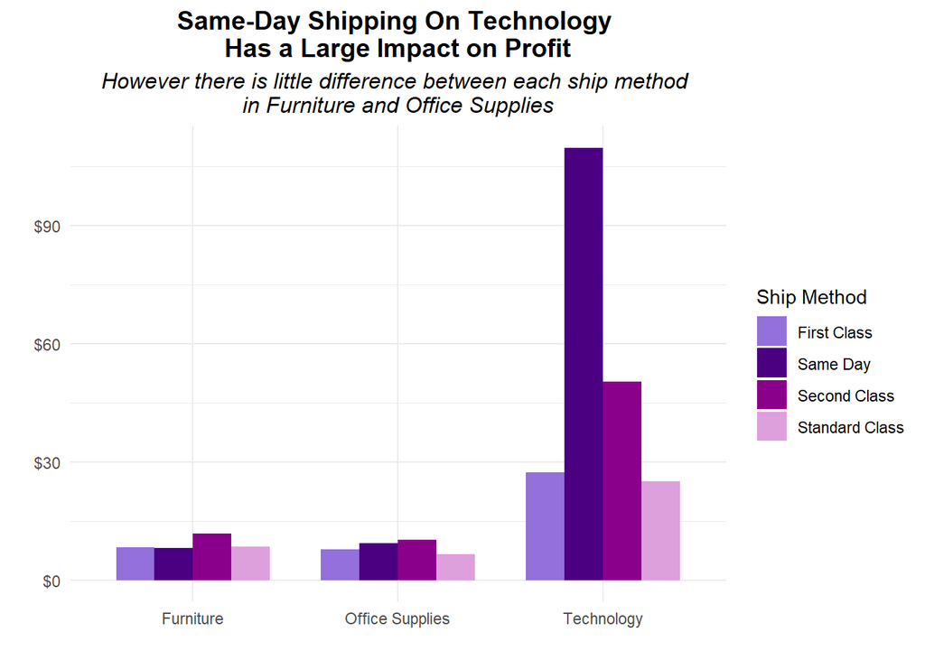

```r
options(scipen = 999)
# increasing profit depending on ship method?
final_ship_toasted <- od %>%
  group_by(Segment, Category, Ship.Mode) %>%
  summarise(med_revenue = median(Profit)) %>%
  #filter(any(Category = 'Technology')) %>%
  ggplot(aes(x = factor(Category), y = med_revenue, group = Ship.Mode, fill = as.factor(Ship.Mode))) +
  geom_bar(stat = "identity",width = 0.75, position = "dodge")+
  #annotate("text",x =1, y = 27, label = "NO DISCOUNT", size = 2)+
  scale_fill_manual(values =c("#9370DB","#4B0082","#8B008B","#DDA0DD"), name = "Ship Method")+
  theme_minimal()+
  labs(x = "", y = "", title = "Same-Day Shipping On Technology \nHas a Large Impact on Profit",
       subtitle = "However there is little difference between each ship method \nin Furniture and Office Supplies") +
  theme(plot.title = element_text(face = "bold", hjust = 0.5, size = 14),
        plot.subtitle = element_text(hjust = 0.5, face = "italic", size = 12),
        axis.title.x = element_text(size = 10)) +
  scale_y_continuous(labels = dollar)

ship_final <- final_ship_toasted
  #theme(legend.position = "none")

ship_final
```

## 11.2 Discount Impact on Profit

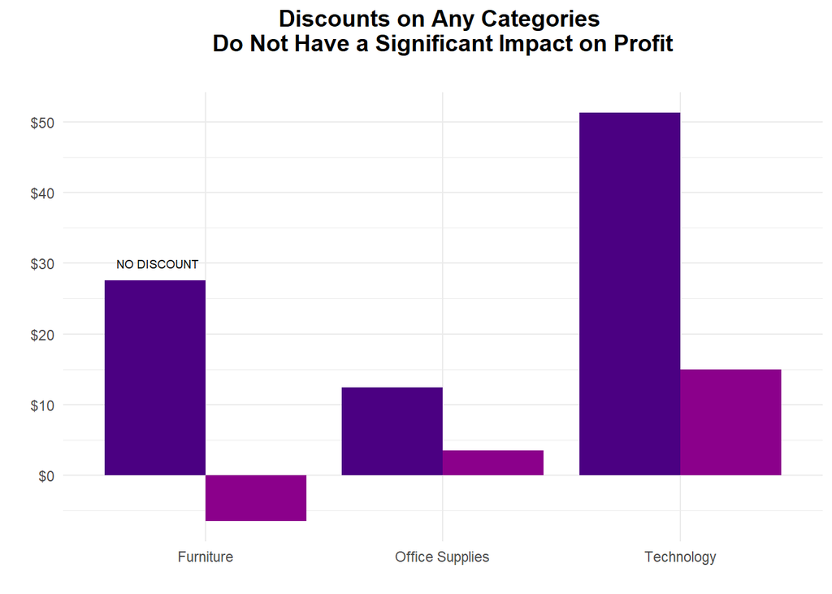

```r
options(scipen = 999)
# increasing profit with discounts?
final_disc_toasted <- od %>%
  group_by(Segment, Category, discount_eligible) %>%
  summarise(med_revenue = median(Profit)) %>%
  #filter(any(Category = 'Technology')) %>%
  ggplot(aes(x = factor(Category), y = med_revenue, group = discount_eligible, fill = as.factor(discount_eligible))) +
  geom_bar(stat = "identity",width = 0.85, position = "dodge")+
           #position = position_dodge())+
  annotate("text",x =0.8, y = 30, label = "NO DISCOUNT", size = 2.5)+
  scale_fill_manual(values =c("#4B0082","#8B008B"), name = "DISCOUNT")+
  theme_minimal()+
  labs(x = "", y = "", title = "Discounts on Any Categories \nDo Not Have a Significant Impact on Profit",
       subtitle = "") +
  theme(plot.title = element_text(face = "bold", hjust = 0.5, size = 14),
        plot.subtitle = element_text(hjust = 0.5, face = "italic", size = 12),
        axis.title.x = element_text(size = 10)) +
  scale_y_continuous(labels = dollar)

final_disc <- final_disc_toasted + theme(legend.position = "none")

final_disc
```

## 11.3 Save Visuals for Later Use

```r
# toasted flavor revenue for promos
ggsave(filename = "shipping.png", plot = ship_final)
# cocoa flavor revenue for ads
ggsave(filename = "discounts.png", plot = final_disc)
```